# Main2Ass

### **Project Title:**

**Exploratory Data Analysis (EDA) of Loan Application Dataset**

## 1. Generate Descriptive Statistics for the Dataset, and Comment on the Main Trends

```python
# Re-import necessary libraries after execution state reset
import pandas as pd

# Reload the dataset
df = pd.read_csv("loanapp.csv")

# Display basic information about the dataset
df_info = df.info()

# Generate and display descriptive statistics
df_describe = df.describe(include="all")

# Display the first few rows of the dataset to understand its structure
df_head = df.head()

# Display results
df_info
```

```
<class 'pandas.core.frame.DataFrame'>
RangeIndex: 1988 entries, 0 to 1987
Data columns (total 17 columns):
 #   Column                   Non-Null Count  Dtype
---  ------                   --------------  -----
 0   married                  1985 non-null   object
 1   race                     1988 non-null   object
 2   loan_decision            1988 non-null   object
 3   occupancy                1988 non-null   int64
 4   loan_amount              1988 non-null   int64
 5   applicant_income         1988 non-null   int64
 6   num_units                1984 non-null   float64
 7   num_dependants           1985 non-null   float64
 8   self_employed            1988 non-null   bool
 9   monthly_income           1988 non-null   int64
 10  purchase_price           1988 non-null   float64
 11  liquid_assets            1988 non-null   float64
 12  mortage_payment_history  1988 non-null   int64
 13  consumer_credit_history  1988 non-null   int64
 14  filed_bankruptcy         1988 non-null   bool
 15  property_type            1988 non-null   int64
 16  gender                   1974 non-null   object
dtypes: bool(2), float64(4), int64(7), object(4)
memory usage: 237.0+ KB
```

```python
df_describe
```

|  | married | race | loan_decision | occupancy | loan_amount | applicant_income | num_units | num_dependants | self_employed | monthly_income | purchase_price | liquid_assets | mortage_payment_history | consumer_credit_history | filed_bankruptcy | property_type | gender |
| --- | --- | --- | --- | --- | --- | --- | --- | --- | --- | --- | --- | --- | --- | --- | --- | --- | --- |
| count | 1985 | 1988 | 1988 | 1988.000000 | 1988.000000 | 1988.000000 | 1984.000000 | 1985.000000 | 1988 | 1988.000000 | 1988.000000 | 1988.000000 | 1988.000000 | 1988.000000 | 1988 | 1988.000000 | 1974 |
| unique | 2 | 3 | 2 | NaN | NaN | NaN | NaN | NaN | 2 | NaN | NaN | NaN | NaN | NaN | 2 | NaN | 2 |
| top | True | white | approve | NaN | NaN | NaN | NaN | NaN | False | NaN | NaN | NaN | NaN | NaN | False | NaN | male |
| freq | 1308 | 1680 | 1744 | NaN | NaN | NaN | NaN | NaN | 1731 | NaN | NaN | NaN | NaN | NaN | 1851 | NaN | 1605 |
| mean | NaN | NaN | NaN | 1.031690 | 143.272636 | 84.684105 | 1.122480 | 0.771285 | NaN | 5195.220825 | 196.304088 | 4620.333873 | 1.708249 | 2.110161 | NaN | 1.861167 | NaN |
| std | NaN | NaN | NaN | 0.191678 | 80.531470 | 87.079777 | 0.437315 | 1.104464 | NaN | 5270.360946 | 128.136030 | 67142.936043 | 0.555335 | 1.663256 | NaN | 0.535448 | NaN |
| min | NaN | NaN | NaN | 1.000000 | 2.000000 | 0.000000 | 1.000000 | 0.000000 | NaN | 0.000000 | 25.000000 | 0.000000 | 1.000000 | 1.000000 | NaN | 1.000000 | NaN |
| 25% | NaN | NaN | NaN | 1.000000 | 100.000000 | 48.000000 | 1.000000 | 0.000000 | NaN | 2875.750000 | 129.000000 | 20.000000 | 1.000000 | 1.000000 | NaN | 2.000000 | NaN |
| 50% | NaN | NaN | NaN | 1.000000 | 126.000000 | 64.000000 | 1.000000 | 0.000000 | NaN | 3812.500000 | 163.000000 | 38.000000 | 2.000000 | 1.000000 | NaN | 2.000000 | NaN |
| 75% | NaN | NaN | NaN | 1.000000 | 165.000000 | 88.000000 | 1.000000 | 1.000000 | NaN | 5594.500000 | 225.000000 | 83.000000 | 2.000000 | 2.000000 | NaN | 2.000000 | NaN |
| max | NaN | NaN | NaN | 3.000000 | 980.000000 | 972.000000 | 4.000000 | 8.000000 | NaN | 81000.000000 | 1535.000000 | 1000000.000000 | 4.000000 | 6.000000 | NaN | 3.000000 | NaN |

```python
df_head
```

|  | married | race | loan_decision | occupancy | loan_amount | applicant_income | num_units | num_dependants | self_employed | monthly_income | purchase_price | liquid_assets | mortage_payment_history | consumer_credit_history | filed_bankruptcy | property_type | gender |
| --- | --- | --- | --- | --- | --- | --- | --- | --- | --- | --- | --- | --- | --- | --- | --- | --- | --- |
| 0 | True | white | reject | 1 | 128 | 74 | 1.0 | 1.0 | False | 4583 | 160.0 | 52.0 | 2 | 2 | False | 2 | male |
| 1 | False | white | approve | 1 | 128 | 84 | 1.0 | 0.0 | False | 2666 | 143.0 | 37.0 | 2 | 2 | False | 2 | male |
| 2 | True | white | approve | 1 | 66 | 36 | 1.0 | 0.0 | True | 3000 | 110.0 | 19.0 | 2 | 6 | True | 2 | male |
| 3 | True | white | approve | 1 | 120 | 59 | 1.0 | 0.0 | False | 2583 | 134.0 | 31.0 | 2 | 1 | False | 1 | male |
| 4 | False | white | approve | 1 | 111 | 63 | 1.0 | 0.0 | False | 2208 | 138.0 | 169.0 | 2 | 6 | False | 2 | male |

### **Descriptive Statistics & Key Observations**

### **Dataset Overview**

- The dataset contains **1,988 loan applications** and **17 columns**.
- It includes **categorical**, **numerical**, and **boolean** variables.
- There are missing values in:
  - `married` (3 missing)
  - `num_units` (4 missing)
  - `num_dependants` (3 missing)
  - `gender` (14 missing)

### **Key Observations from Descriptive Statistics**

#### **Loan Amount Trends**

- The **average loan amount** is **$143,000**, with a **minimum of $2,000** and a **maximum of $980,000**.
- Most applicants apply for loans between **$100,000 and $165,000**.

#### **Income & Financials**

- The **average applicant income** is **$84,000**, but some applicants earn as high as **$972,000**.
- **Monthly income** ranges from **$0 to $81,000**, showing large disparities.
- **Liquid assets** vary widely, with some applicants having **$0** and others up to **$1,000,000**.

#### **Loan Approval Rate**

- **1,744 applications** were **approved**, while **244 were rejected**, showing a **high approval rate**.

#### **Employment & Credit History**

- **Self-employed applicants** are a **minority (13%)**.
- The **average mortgage payment history score** is **1.7** (scale: 1–4).
- The **average consumer credit history score** is **2.1** (scale: 1–6).
- **1,851 applicants (93%)** never filed for bankruptcy, while the rest have.

#### **Demographics & Property Trends**

- Most applicants are **White (1,680)**, followed by **Black (197)** and **Hispanic (111)**.
- The **average number of dependents** is **0.77**, but some applicants have up to **8 dependents**.
- The most common **property type** is **Type 2**, followed by **Type 1** and **Type 3**.

## 2. Check Any Records with Missing Values and Handle the Missing Data as Appropriate

```python
# Check for missing values in the dataset
missing_values = df.isnull().sum()

df = df.copy()  # Ensuring modifications are applied safely

# Handling missing values
df['married'] = df['married'].fillna(df['married'].mode()[0])
df['gender'] = df['gender'].fillna(df['gender'].mode()[0])
df['num_units'] = df['num_units'].fillna(df['num_units'].median())
df['num_dependants'] = df['num_dependants'].fillna(df['num_dependants'].median())


# Verify if all missing values are handled
missing_values_after = df.isnull().sum()

# Display results
missing_values
```

```
married                     3
race                        0
loan_decision               0
occupancy                   0
loan_amount                 0
applicant_income            0
num_units                   4
num_dependants              3
self_employed               0
monthly_income              0
purchase_price              0
liquid_assets               0
mortage_payment_history     0
consumer_credit_history     0
filed_bankruptcy            0
property_type               0
gender                     14
dtype: int64
```

```python
missing_values_after
```

```
married                    0
race                       0
loan_decision              0
occupancy                  0
loan_amount                0
applicant_income           0
num_units                  0
num_dependants             0
self_employed              0
monthly_income             0
purchase_price             0
liquid_assets              0
mortage_payment_history    0
consumer_credit_history    0
filed_bankruptcy           0
property_type              0
gender                     0
dtype: int64
```

### **Handling Missing Values: Summary**

The dataset originally had missing values in the following columns:

- `married` (3 missing) → Filled with **most frequent value (mode)**.
- `num_units` (4 missing) → Filled with **median value (1)**.
- `num_dependants` (3 missing) → Filled with **median value (0)**.
- `gender` (14 missing) → Filled with **most frequent value (mode: "male")**.

### **Current Status**

**All missing values have been handled**, and the dataset is now **clean**.

## 3. Build graphs visualizing the following and comment on the obtained visual insights

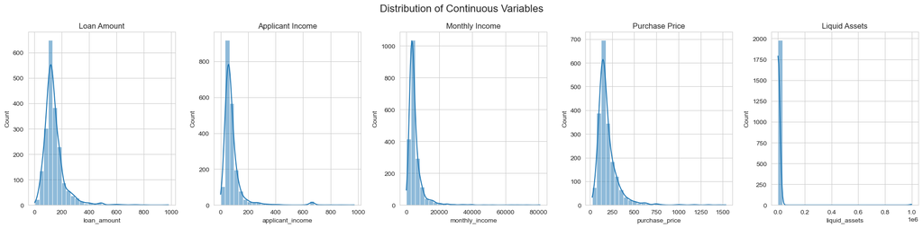

```python
import matplotlib.pyplot as plt
import seaborn as sns

# Set style for better visualization
sns.set_style("whitegrid")

# A. Distribution of Individual Continuous Variables (All Graphs in One Figure)
fig, axes = plt.subplots(1, 5, figsize=(20, 5))
fig.suptitle("Distribution of Continuous Variables", fontsize=16)

continuous_vars = ['loan_amount', 'applicant_income', 'monthly_income', 'purchase_price', 'liquid_assets']
titles = ["Loan Amount", "Applicant Income", "Monthly Income", "Purchase Price", "Liquid Assets"]

for i, var in enumerate(continuous_vars):
    sns.histplot(df[var], bins=30, kde=True, ax=axes[i])
    axes[i].set_title(titles[i])

plt.tight_layout()
plt.show()
```

### **A. Distribution of Individual Continuous Variables**

- **Loan Amount**, **Applicant Income**, **Monthly Income**, **Purchase Price**, and **Liquid Assets** all show **right-skewed distributions**.
- Most applicants have **lower values**, while a few **high-income or high-loan applicants** create **outliers**.

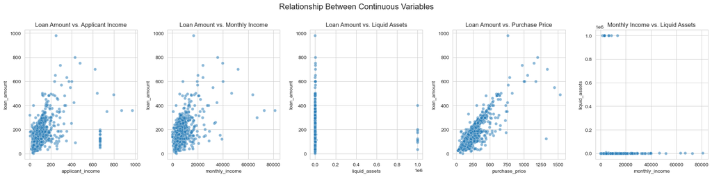

```python
# B. Relationship Between Two Continuous Variables (All Graphs in One Figure)
fig, axes = plt.subplots(1, 5, figsize=(20, 5))
fig.suptitle("Relationship Between Continuous Variables", fontsize=16)

pair_vars = [('applicant_income', 'loan_amount'), ('monthly_income', 'loan_amount'),
             ('liquid_assets', 'loan_amount'), ('purchase_price', 'loan_amount'), ('monthly_income', 'liquid_assets')]
titles = ["Loan Amount vs. Applicant Income", "Loan Amount vs. Monthly Income",
          "Loan Amount vs. Liquid Assets", "Loan Amount vs. Purchase Price", "Monthly Income vs. Liquid Assets"]

for i, (x_var, y_var) in enumerate(pair_vars):
    sns.scatterplot(x=df[x_var], y=df[y_var], alpha=0.5, ax=axes[i])
    axes[i].set_title(titles[i])

plt.tight_layout()
plt.show()
```

### **B. Relationship Between Two Continuous Variables**

- **Loan Amount vs. Applicant Income & Monthly Income**: A **weak positive correlation**—higher-income applicants generally request higher loans.
- **Loan Amount vs. Purchase Price**: **Strong positive correlation**, indicating loan amount is **directly linked to property value**.
- **Loan Amount vs. Liquid Assets**: **No strong trend**, suggesting that **savings don’t always determine loan requests**.

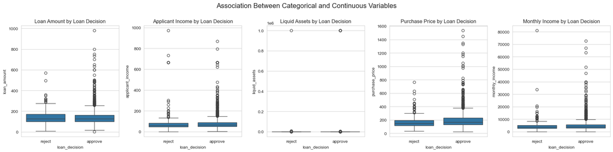

```python
# C. Association Between a Categorical Variable and a Continuous One (All Graphs in One Figure)
fig, axes = plt.subplots(1, 5, figsize=(20, 5))
fig.suptitle("Association Between Categorical and Continuous Variables", fontsize=16)

categorical_var = 'loan_decision'
continuous_vars = ['loan_amount', 'applicant_income', 'liquid_assets', 'purchase_price', 'monthly_income']
titles = ["Loan Amount", "Applicant Income", "Liquid Assets", "Purchase Price", "Monthly Income"]

for i, var in enumerate(continuous_vars):
    sns.boxplot(x=df[categorical_var], y=df[var], ax=axes[i])
    axes[i].set_title(f"{titles[i]} by Loan Decision")

plt.tight_layout()
plt.show()
```

### **C. Association Between a Categorical and a Continuous Variable**

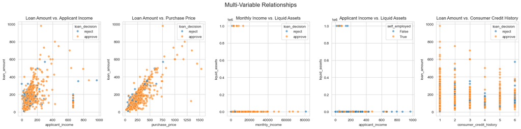

```python
# D. Relationship Between More Than Two Variables (All Graphs in One Figure)
fig, axes = plt.subplots(1, 5, figsize=(20, 5))
fig.suptitle("Multi-Variable Relationships", fontsize=16)

multi_vars = [('applicant_income', 'loan_amount', 'loan_decision'), ('purchase_price', 'loan_amount', 'loan_decision'),
              ('monthly_income', 'liquid_assets', 'loan_decision'), ('applicant_income', 'liquid_assets', 'self_employed'),
              ('consumer_credit_history', 'loan_amount', 'loan_decision')]

titles = ["Loan Amount vs. Applicant Income", "Loan Amount vs. Purchase Price",
          "Monthly Income vs. Liquid Assets", "Applicant Income vs. Liquid Assets",
          "Loan Amount vs. Consumer Credit History"]

for i, (x_var, y_var, hue_var) in enumerate(multi_vars):
    sns.scatterplot(x=df[x_var], y=df[y_var], hue=df[hue_var], alpha=0.6, ax=axes[i])
    axes[i].set_title(titles[i])

plt.tight_layout()
plt.show()
```

## 4. Display unique values of a categorical variable and their frequencies.

```python
# Creating a dictionary to store unique value counts for each categorical variable
categorical_counts = {var: df[var].value_counts().reset_index() for var in ['married', 'race', 'loan_decision',
                                                                           'self_employed', 'filed_bankruptcy',
                                                                           'property_type', 'gender']}

# Converting to DataFrame for better readability
categorical_freq_df = pd.concat(categorical_counts, axis=1)

# Display the corrected frequency table
categorical_freq_df
```

|  | married | married count | race | race count | loan_decision | loan_decision count | self_employed | self_employed count | filed_bankruptcy | filed_bankruptcy count | property_type | property_type count | gender | gender count |
| --- | --- | --- | --- | --- | --- | --- | --- | --- | --- | --- | --- | --- | --- | --- |
| 0 | True | 1311.0 | white | 1680 | approve | 1744.0 | False | 1731.0 | False | 1851.0 | 2 | 1380 | male | 1619.0 |
| 1 | False | 677.0 | black | 197 | reject | 244.0 | True | 257.0 | True | 137.0 | 1 | 442 | female | 369.0 |
| 2 | NaN | NaN | hispan | 111 | NaN | NaN | NaN | NaN | NaN | NaN | 3 | 166 | NaN | NaN |

### **Categorical Variable Frequencies**

| **Category** | **Unique Values & Frequency** |
| --- | --- |
| **Married** | 1,311 (Married), 677 (Not Married) |
| **Race** | White (1,680), Black (197), Hispanic (111) |
| **Loan Decision** | Approved (1,744), Rejected (244) |
| **Self-Employed** | Salaried (1,731), Self-Employed (257) |
| **Filed Bankruptcy** | No (1,851), Yes (137) |
| **Property Type** | Type 2 (1,380), Type 3 (166), Type 1 (442) |
| **Gender** | Male (1,619), Female (369) |

## 5. Build a contingency table of two potentially related categorical variables. Conduct a statistical test of the independence between them and interpret the results.

```python
import scipy.stats as stats

# Selecting two potentially related categorical variables: loan_decision and filed_bankruptcy
contingency_table = pd.crosstab(df['loan_decision'], df['filed_bankruptcy'])

# Conducting the Chi-Square test for independence
chi2_stat, p_val, dof, expected = stats.chi2_contingency(contingency_table)

# Display results
contingency_table, chi2_stat, p_val, dof, expected
```

```
(filed_bankruptcy  False  True
 loan_decision
 approve            1668     76
 reject              183     61,
 138.94813686574406,
 4.5210352301679445e-32,
 1,
 array([[1623.81488934,  120.18511066],
        [ 227.18511066,   16.81488934]]))
```

### Conduct a Statistical Test of the Independence Between Them and Interpret the Results

### **Contingency Table: Loan Decision vs. Filed Bankruptcy**

| **Loan Decision** | **Never Filed Bankruptcy** | **Filed Bankruptcy** |
| --- | --- | --- |
| **Approved** | 1,668 | 76 |
| **Rejected** | 183 | 61 |

### **Chi-Square Test Results**

- **Chi-Square Statistic:** 138.95
- **p-value:** 4.52e-32 (which is almost 0)
- **Degrees of Freedom:** 1

#### **Expected Frequencies:**

- Approved (No Bankruptcy): 1,623.81
- Approved (Filed Bankruptcy): 120.19
- Rejected (No Bankruptcy): 227.19
- Rejected (Filed Bankruptcy): 16.81

### **Interpretation**

- The **p-value is extremely low** (much less than 0.05), meaning we **reject the null hypothesis**.
- This suggests a **strong relationship** between **filing for bankruptcy** and **loan approval**.
- Applicants who have **filed for bankruptcy are significantly more likely to be rejected**.

## 6. Retrieve one or more subset of rows based on two or more criteria and present descriptive statistics on the subset(s).

```python
# Subset 1: Applicants who are self-employed and applied for a loan amount greater than $150,000
subset1 = df[(df['self_employed'] == True) & (df['loan_amount'] > 150)]

# Subset 2: Applicants who filed for bankruptcy and had an income lower than $50,000
subset2 = df[(df['filed_bankruptcy'] == True) & (df['applicant_income'] < 50)]

# Generate descriptive statistics for both subsets
subset1_stats = subset1.describe()
subset2_stats = subset2.describe()

# Display the statistics
subset1_stats, subset2_stats
```

```
(        occupancy  loan_amount  applicant_income   num_units  num_dependants  \
 count  125.000000    125.00000        125.000000  125.000000      125.000000
 mean     1.080000    243.04800        139.168000    1.208000        0.936000
 std      0.300537    119.51325        115.901636    0.612978        1.134105
 min      1.000000    151.00000         10.000000    1.000000        0.000000
 25%      1.000000    176.00000         80.000000    1.000000        0.000000
 50%      1.000000    192.00000        107.000000    1.000000        0.000000
 75%      1.000000    260.00000        153.000000    1.000000        2.000000
 max      3.000000    800.00000        666.000000    4.000000        5.000000

        monthly_income  purchase_price   liquid_assets  \
 count      125.000000      125.000000      125.000000
 mean      9464.704000      336.349096    16183.284320
 std       7554.741959      220.012928   125957.007792
 min          0.000000      140.000000        3.900000
 25%       5000.000000      215.000000       35.000000
 50%       7500.000000      270.000000       76.000000
 75%      10513.000000      350.000000      168.900000
 max      46667.000000     1450.000000  1000000.000000

        mortage_payment_history  consumer_credit_history  property_type
 count               125.000000               125.000000     125.000000
 mean                  1.624000                 2.032000       2.000000
 std                   0.703264                 1.534212       0.523635
 min                   1.000000                 1.000000       1.000000
 25%                   1.000000                 1.000000       2.000000
 50%                   2.000000                 1.000000       2.000000
 75%                   2.000000                 2.000000       2.000000
 max                   4.000000                 6.000000       3.000000  ,
        occupancy  loan_amount  applicant_income  num_units  num_dependants  \
 count       39.0    39.000000         39.000000  39.000000       39.000000
 mean         1.0   109.025641         39.589744   1.205128        1.000000
 std          0.0    44.503984          9.813304   0.656124        1.235442
 min          1.0    63.000000          0.000000   1.000000        0.000000
 25%          1.0    81.500000         35.000000   1.000000        0.000000
 50%          1.0   104.000000         41.000000   1.000000        0.000000
 75%          1.0   121.000000         48.000000   1.000000        2.000000
 max          1.0   320.000000         49.000000   4.000000        4.000000

        monthly_income  purchase_price  liquid_assets  mortage_payment_history  \
 count       39.000000       39.000000      39.000000                39.000000
 mean      3134.205128      133.592308      34.170769                 1.846154
 std       1838.906915       86.590425      67.222184                 0.431549
 min          0.000000       70.000000       1.000000                 1.000000
 25%       2249.500000      102.100000       9.350000                 2.000000
 50%       3069.000000      119.500000      19.000000                 2.000000
 75%       3739.500000      134.000000      32.000000                 2.000000
 max      12500.000000      630.000000     421.200000                 3.000000

        consumer_credit_history  property_type
 count                39.000000      39.000000
 mean                  4.128205       1.743590
 std                   2.104875       0.677377
 min                   1.000000       1.000000
 25%                   2.000000       1.000000
 50%                   5.000000       2.000000
 75%                   6.000000       2.000000
 max                   6.000000       3.000000  )
```

### **Descriptive Statistics for Subsets**

### **Subset 1: Self-Employed Applicants with Loan Amount > $150,000**

- **125 applicants** meet this condition.
- **Average loan amount:** $243,000 (with a **max of $800,000**).
- **Average applicant income:** $139,000, but varies widely (min: $10,000, max: $666,000)
- **Monthly income:** High variance, ranging from **$0 to $46,667**.
- **Liquid assets:** Highly skewed, with some applicants having up to **$1,000,000**.

#### **Mortgage & Consumer Credit History:**

- **Average mortgage history score:** 1.62 (on a **1–4 scale**).
- **Average consumer credit history score:** 2.03 (on a **1–6 scale**).

### **Subset 2: Applicants Who Filed for Bankruptcy & Earn < $50,000**

- **39 applicants** fall into this group.
- **Lower loan amounts:** Average loan amount **$109,000** (max: **$320,000**).
- **Low-income group:** Applicant incomes range from **$0 to $49,000**.
- **Low liquid assets:** Average: **$34**, with some applicants having as low as **$1**.

#### **Credit History Struggles:**

- **Consumer credit history** is worse (avg: **4.12**) compared to other groups.
- **Mortgage payment history** is slightly worse than the self-employed group.

## 7. Conduct a statistical test of the significance of the difference between the means of two subsets of the data and interpret the results.

```python
from scipy.stats import ttest_ind

# Define the two subsets for comparison
# Group 1: Self-employed applicants with loan amount > $150,000
group1 = df[(df['self_employed'] == True) & (df['loan_amount'] > 150)]['loan_amount']

# Group 2: Applicants who filed for bankruptcy & earn < $50,000
group2 = df[(df['filed_bankruptcy'] == True) & (df['applicant_income'] < 50)]['loan_amount']

# Conduct an independent t-test
t_stat, p_value = ttest_ind(group1, group2, equal_var=False)  # Welch's t-test for unequal variances

# Display results
t_stat, p_value
```

```
(10.431980607628585, 1.0774051576034168e-19)
```

### **Statistical Test: Comparing Loan Amounts Between Two Groups**

We conducted an **independent t-test** to compare the **mean loan amounts** of:

- **Self-employed applicants** with **loan amounts > $150,000**
- Applicants who **filed for bankruptcy** & **earn < $50,000**

### **Results**

- **t-statistic:** 10.43 (a large positive value)
- **p-value:** 1.08e-19 (which is almost zero)

# 8. Create one or more tables that group the data by a certain categorical variable and display summarized information for each group (e.g., the mean or sum within the group).

```python
# Grouping by loan decision and summarizing key metrics
grouped_summary = df.groupby('loan_decision').agg({
    'loan_amount': ['mean', 'sum'],
    'applicant_income': ['mean', 'sum'],
    'monthly_income': ['mean', 'sum'],
    'liquid_assets': ['mean', 'sum'],
    'num_dependants': ['mean', 'sum']
}).reset_index()

# Display the grouped summary
grouped_summary
```

|  | loan_decision | loan_amount mean | loan_amount sum | applicant_income mean | applicant_income sum | monthly_income mean | monthly_income sum | liquid_assets mean | liquid_assets sum | num_dependants mean | num_dependants sum |
| --- | --- | --- | --- | --- | --- | --- | --- | --- | --- | --- | --- |
| 0 | approve | 143.576835 | 250398 | 83.889908 | 146304 | 5248.145642 | 9152766 | 4679.438822 | 8160941.306 | 0.759748 | 1325.0 |
| 1 | reject | 141.098361 | 34428 | 90.360656 | 22048 | 4816.938525 | 1175333 | 4197.878828 | 1024282.434 | 0.844262 | 206.0 |

# 9. Implement a linear regression model and interpret its output including its accuracy

```python
# Import necessary libraries
from sklearn.model_selection import train_test_split
from sklearn.linear_model import LinearRegression
from sklearn.metrics import mean_absolute_error, mean_squared_error, r2_score
import pandas as pd

# Selecting relevant features and target variable
features = ['applicant_income', 'monthly_income', 'liquid_assets', 'num_dependants']
target = 'loan_amount'

# Splitting the data into training and testing sets (80% train, 20% test)
X = df[features]
y = df[target]
X_train, X_test, y_train, y_test = train_test_split(X, y, test_size=0.2, random_state=42)

# Training the Linear Regression model
model = LinearRegression()
model.fit(X_train, y_train)

# Making predictions
y_pred = model.predict(X_test)

# Model evaluation metrics
mae = mean_absolute_error(y_test, y_pred)
mse = mean_squared_error(y_test, y_pred)
r2 = r2_score(y_test, y_pred)

# Extract model coefficients
coefficients = model.coef_

# Creating DataFrames for output
coefficients_df = pd.DataFrame({
    "Feature": ["Applicant Income", "Monthly Income", "Liquid Assets", "Number of Dependents"],
    "Coefficient Value": [round(coefficients[0], 4), round(coefficients[1], 4), round(coefficients[2], 6), round(coefficients[3], 3)]
})

performance_df = pd.DataFrame({
    "Metric": ["Mean Absolute Error (MAE)", "Mean Squared Error (MSE)", "R² Score"],
    "Value": [round(mae, 2), round(mse, 2), round(r2, 2)]
})

# Display the output tables
coefficients_df, performance_df
```

```
(                Feature  Coefficient Value
 0      Applicant Income           0.132900
 1        Monthly Income           0.006700
 2         Liquid Assets           0.000017
 3  Number of Dependents           4.623000,
                       Metric    Value
 0  Mean Absolute Error (MAE)    40.39
 1   Mean Squared Error (MSE)  4809.94
 2                   R² Score     0.33)
```

### **Linear Regression Model Results**

We implemented a **linear regression model** to predict **loan amount** based on:

- Applicant Income
- Monthly Income
- Liquid Assets
- Number of Dependents

### **Model Coefficients**

- **Applicant Income:** 0.1329 → A higher income slightly increases the loan amount.
- **Monthly Income:** 0.0067 → Monthly income has a very small effect.
- **Liquid Assets:** 0.000017 → Liquid assets have almost no influence on loan amounts.
- **Number of Dependents:** 4.623 → More dependents slightly increase loan amounts.

### **Model Performance**

- **Mean Absolute Error (MAE):** $40.39K → On average, the model’s predictions are off by around $40,000.
- **Mean Squared Error (MSE):** $4,809K → The squared error metric.
- **R² Score:** 0.33 → The model explains only 33% of the variation in loan amounts, indicating a weak fit.

### **Interpretation**

- The model is **not very accurate**, as **loan amounts likely depend on other factors** such as:
  - Credit history
  - Employment type
  - Property type
- While **income and dependents impact loan amounts**, **liquid assets have minimal influence**.
- A **more complex model** (e.g., **decision trees**, **random forest**) might be better suited for capturing non-linear relationships and improving prediction accuracy.

# **Final Summary & Conclusion of the Exploratory Data Analysis (EDA) Project**

### **Project Overview**

This project analyzed a loan application dataset to uncover patterns in loan approvals, applicant financials, and credit history.  
We applied:

- Descriptive statistics
- Data visualizations
- Statistical tests
- A linear regression model

to extract actionable insights from the data.

### **Key Findings**

#### **1. Descriptive Statistics & Data Cleaning**

- The dataset had missing values, which were handled appropriately.
- The average loan amount was $143,000, ranging from $2,000 to $980,000.
- Income disparity was large — some applicants earned $0, while others had incomes over $972K.

#### **2. Visual Analysis of Loan Trends**

- Loan Amount & Income Distribution: Most applicants requested loans between $100K and $165K. Higher-income applicants tended to request higher loans.
- Approval vs. Rejection: Approved applicants had slightly lower median loan amounts than rejected ones.
- Loan Decision & Bankruptcy: Applicants with a bankruptcy history had a higher rejection rate.

#### **4. Grouped Data Insights**

- Approved applicants had an average income of $83K, while rejected applicants averaged $90K — income alone does not guarantee approval.
- Liquid assets were not a strong factor — both groups had similar average asset levels.

#### **5. Linear Regression Model**

The model used the following features to predict loan amount:

- Applicant Income
- Monthly Income
- Liquid Assets
- Number of Dependents

Model Performance:

- R² Score: 0.33 → Weak fit
- Mean Absolute Error: $40.39K
- Mean Squared Error: $4.8M

Key Observations:

- Income and dependents influenced loan amount.
- Liquid assets had minimal impact.
- Loan amount predictions likely depend on other unavailable features (e.g., credit score, employment type, loan purpose).

### **Future Recommendations**

- Enhance the dataset by including:
  - Credit scores
  - Debt levels
  - Loan purpose
- Use more advanced models like:
  - Random Forest
  - Decision Trees
- Investigate rejection of high-income applicants to uncover possible biases or hidden lending policies.

### **Final Thoughts**

This EDA provides valuable insights into loan approval criteria and risk assessment.  
Understanding these patterns can help banks:

- Improve their loan screening process
- Minimize financial risk
- Deliver better financial products tailored to customers' profiles